# SI618 Final Project_jiaou-yxmin

## Read, clean and manipulate the data sets

```python
import pandas as pd
import matplotlib.pyplot as plt
import seaborn as sns
import warnings
warnings.filterwarnings("ignore")
```

First, we read the main data set (the crashes data) from the csv file:

```python
crash_total = pd.read_csv("Motor_Vehicle_Collisions_-_Crashes.csv")
```

We focused on the 2019 data since COVID-19 reduced traffic by decreasing tourism and encouraging people to stay home. This made data after 2019 less reliable, so we isolated the crash data from 2019.

```python
crash_total = crash_total[crash_total['CRASH DATE'].str.contains('2019')]
crash_total.to_csv("crash_2019.csv", encoding='utf-8', index=False)
```

Then we look at the information of the data set to estimate the number of missing values:

```python
crash_total.info()
```

```
<class 'pandas.core.frame.DataFrame'>
Index: 211486 entries, 450 to 722513
Data columns (total 29 columns):
 #   Column                         Non-Null Count   Dtype
---  ------                         --------------   -----
 0   CRASH DATE                     211486 non-null  object
 1   CRASH TIME                     211486 non-null  object
 2   BOROUGH                        137024 non-null  object
 3   ZIP CODE                       136979 non-null  object
 4   LATITUDE                       194114 non-null  float64
 5   LONGITUDE                      194114 non-null  float64
 6   LOCATION                       194114 non-null  object
 7   ON STREET NAME                 160486 non-null  object
 8   CROSS STREET NAME              104201 non-null  object
 9   OFF STREET NAME                50972 non-null   object
```

[output cut: 21 more lines]

Next, we read the secondary data sets from the csv files.

```python
# read weather data
temp = pd.read_csv('nyc_temperature.csv')
temp.head(5)
```

|  | date | tmax | tmin | tavg | departure | HDD | CDD | precipitation | new_snow | snow_depth |
| --- | --- | --- | --- | --- | --- | --- | --- | --- | --- | --- |
| 0 | 1/1/19 | 60 | 40 | 50.0 | 13.9 | 15 | 0 | 0.08 | 0 | 0 |
| 1 | 2/1/19 | 41 | 35 | 38.0 | 2.1 | 27 | 0 | 0 | 0 | 0 |
| 2 | 3/1/19 | 45 | 39 | 42.0 | 6.3 | 23 | 0 | T | 0 | 0 |
| 3 | 4/1/19 | 47 | 37 | 42.0 | 6.5 | 23 | 0 | 0 | 0 | 0 |
| 4 | 5/1/19 | 47 | 42 | 44.5 | 9.1 | 20 | 0 | 0.45 | 0 | 0 |

```python
temp.info()
```

```
<class 'pandas.core.frame.DataFrame'>
RangeIndex: 365 entries, 0 to 364
Data columns (total 10 columns):
 #   Column         Non-Null Count  Dtype
---  ------         --------------  -----
 0   date           365 non-null    object
 1   tmax           365 non-null    int64
 2   tmin           365 non-null    int64
 3   tavg           365 non-null    float64
 4   departure      365 non-null    float64
 5   HDD            365 non-null    int64
 6   CDD            365 non-null    int64
 7   precipitation  365 non-null    object
 8   new_snow       365 non-null    object
 9   snow_depth     365 non-null    object
dtypes: float64(2), int64(4), object(4)
memory usage: 28.6+ KB
```

```python
# read speed limit data
speed_limit = pd.read_csv('nyc_speed_limits.csv')
speed_limit.head(5)
```

|  | lat1 | lon1 | lat2 | lon2 | street | speed | signed | region | distance |
| --- | --- | --- | --- | --- | --- | --- | --- | --- | --- |
| 0 | 40.813067 | -73.922943 | 40.813324 | -73.922877 | alexander avenue | 25 | no | Bronx | 0.018025 |
| 1 | 40.827542 | -73.916381 | 40.827817 | -73.917223 | bonner place | 25 | no | Bronx | 0.048041 |
| 2 | 40.868860 | -73.907224 | 40.868857 | -73.907301 | bailey avenue | 25 | no | Bronx | 0.004040 |
| 3 | 40.808913 | -73.894871 | 40.811690 | -73.895601 | barry street | 25 | no | Bronx | 0.195364 |
| 4 | 40.811690 | -73.895601 | 40.812074 | -73.895782 | barry street | 25 | no | Bronx | 0.028166 |

```python
speed_limit.info()
```

```
<class 'pandas.core.frame.DataFrame'>
RangeIndex: 20314 entries, 0 to 20313
Data columns (total 9 columns):
 #   Column    Non-Null Count  Dtype
---  ------    --------------  -----
 0   lat1      20314 non-null  float64
 1   lon1      20314 non-null  float64
 2   lat2      20314 non-null  float64
 3   lon2      20314 non-null  float64
 4   street    20314 non-null  object
 5   speed     20314 non-null  int64
 6   signed    20314 non-null  object
 7   region    20314 non-null  object
 8   distance  20314 non-null  float64
dtypes: float64(5), int64(1), object(3)
memory usage: 1.4+ MB
```

### Data cleaning

In our main dataset, we remove missing values in the crash date, crash time, and street columns. For any missing data related to participant deaths or injuries, we assign a value of zero. Additionally, if a vehicle type is null while the contributing factor is not null, or if the contributing factor is not null while the vehicle type is null, we exclude those records.

```python
# data cleaning
# drop missing values for 'CRASH DATE', 'CRASH TIME', 'ON STREET NAME', 'VEHICLE TYPE CODE 1'
crash_total.dropna(subset=['CRASH DATE', 'CRASH TIME', 'ON STREET NAME',
                   'CONTRIBUTING FACTOR VEHICLE 1', 'VEHICLE TYPE CODE 1'], inplace=True)
# fill in missing values with 0 for number of deaths and injuries
columns_to_fill = [
    'NUMBER OF PERSONS INJURED',
    'NUMBER OF PERSONS KILLED',
    'NUMBER OF PEDESTRIANS INJURED',
    'NUMBER OF PEDESTRIANS KILLED',
    'NUMBER OF CYCLIST INJURED',
    'NUMBER OF CYCLIST KILLED',
    'NUMBER OF MOTORIST INJURED',
    'NUMBER OF MOTORIST KILLED'
]

for column in columns_to_fill:
    crash_total[column].fillna(0, inplace=True)
# identifies and drops records where a contributing factor exists
# but the corresponding vehicle type is missing, and vice versa.
contributing_factor_columns = [
    'CONTRIBUTING FACTOR VEHICLE 1',
    'CONTRIBUTING FACTOR VEHICLE 2',
    'CONTRIBUTING FACTOR VEHICLE 3',
    'CONTRIBUTING FACTOR VEHICLE 4',
    'CONTRIBUTING FACTOR VEHICLE 5'
]

vehicle_type_columns = [
    'VEHICLE TYPE CODE 1',
    'VEHICLE TYPE CODE 2',
    'VEHICLE TYPE CODE 3',
    'VEHICLE TYPE CODE 4',
    'VEHICLE TYPE CODE 5'
]

for factor_col, type_col in zip(contributing_factor_columns, vehicle_type_columns):
    mask1 = (crash_total[factor_col].isnull()) & (
        ~crash_total[type_col].isnull())
    mask2 = (~crash_total[factor_col].isnull()) & (
        crash_total[type_col].isnull())
    crash_total = crash_total.drop(crash_total[mask1].index)
    crash_total = crash_total.drop(crash_total[mask2].index)
```

For the weather data set, we only keep the 'date','precipitation', 'new_snow', 'snow_depth' as columns to be merged. Then we fill the missing values in 'precipitation', 'new_snow' and 'snow_depth' to be 0.

```python
# only keep necessary columns
selected_columns = ['date', 'precipitation', 'new_snow', 'snow_depth']
temp = temp[selected_columns]
# fill in the missing values with 0
temp['precipitation'] = temp['precipitation'].replace('T', 0)
temp['new_snow'] = temp['new_snow'].replace('T', 0)
temp['snow_depth'] = temp['snow_depth'].replace('T', 0)
```

For the speed limit data set, as one street may have a lot of segments with different speed limits, the street name may duplicate in several rows. So, we compute the mean speed limit for a given street and use this as the column to be merged.

```python
aggregated_speed = speed_limit.groupby('street')['speed'].mean().reset_index()
aggregated_speed = aggregated_speed.rename(
    columns={'speed': 'avg_speed_limit'})
aggregated_speed.head(5)
```

|  | street | avg_speed_limit |
| --- | --- | --- |
| 0 | 1 avenue | 25.0 |
| 1 | 1 place | 25.0 |
| 2 | 1 street | 25.0 |
| 3 | 10 avenue | 25.0 |
| 4 | 10 street | 25.0 |

### Merge the secondary data sets with the primary data set

1. For the speed limit dataset, we merged it with the primary data set on the street name. As the case of the letter or spacing of the street name may not exactly match, we first extract the space from the street name column of both datasets, as well as make all letters in lower case.

```python
aggregated_speed['street'] = aggregated_speed['street'].str.lower(
).str.replace(' ', '')
crash_total['ON STREET NAME'] = crash_total['ON STREET NAME'].str.lower(
).str.replace(' ', '')

# Merge the normalized 'aggregated_speed' with 'crash_total' on normalized 'ON STREET NAME'
crash_total = pd.merge(crash_total, aggregated_speed,
                       left_on='ON STREET NAME', right_on='street', how='inner')
```

2. For the weather data set (temp), we perform datetime conversions for 'CRASH DATE' in crash_total and 'date' in temp to unify the format of the date. Then we merge the weather data with the primary data set on date and look at the merged dataset to confirm that both the secondary datasets are merged successfully.

```python
crash_total['Timestamp'] = pd.to_datetime(crash_total['CRASH DATE'])
temp['date'] = pd.to_datetime(temp['date'])
crash_total = pd.merge(
    crash_total, temp, left_on='Timestamp', right_on='date', how='left')
crash_total.head(3)
```

|  | CRASH DATE | CRASH TIME | BOROUGH | ZIP CODE | LATITUDE | LONGITUDE | LOCATION | ON STREET NAME | CROSS STREET NAME | OFF STREET NAME | ... | VEHICLE TYPE CODE 3 | VEHICLE TYPE CODE 4 | VEHICLE TYPE CODE 5 | street | avg_speed_limit | Timestamp | date | precipitation | new_snow | snow_depth |
| --- | --- | --- | --- | --- | --- | --- | --- | --- | --- | --- | --- | --- | --- | --- | --- | --- | --- | --- | --- | --- | --- |
| 0 | 05/21/2019 | 22:50 | BROOKLYN | 11201.0 | 40.697540 | -73.98312 | (40.69754, -73.98312) | goldstreet | CONCORD STREET | NaN | ... | NaN | NaN | NaN | goldstreet | 25.0 | 2019-05-21 | 2019-05-21 | 0 | 0 | 0 |
| 1 | 12/14/2019 | 11:35 | BROOKLYN | 11201.0 | 40.695908 | -73.98322 | (40.695908, -73.98322) | goldstreet | TILLARY STREET | NaN | ... | NaN | NaN | NaN | goldstreet | 25.0 | 2019-12-14 | 2019-12-14 | 1.13 | 0 | 0 |
| 2 | 12/17/2019 | 18:00 | BROOKLYN | 11201.0 | 40.701360 | -73.98286 | (40.70136, -73.98286) | goldstreet | YORK STREET | NaN | ... | NaN | NaN | NaN | goldstreet | 25.0 | 2019-12-17 | 2019-12-17 | 0.9 | 0 | 0 |

3 rows × 36 columns

## Data visualization and analysis

### 1. Visualize the spatial distribution characteristics

First, we use folium to display the density of number of crashes on the map of NYC by heatmap.

```python
import folium
from folium.plugins import HeatMap
# Drop rows with missing latitude or longitude values
crash_total_cleaned = crash_total.dropna(subset=['LATITUDE', 'LONGITUDE'])
m = folium.Map(location=[40.7128, -74.0060], zoom_start=10)
# Extract latitude and longitude information and convert it to a list of lists
crash_coordinates = crash_total_cleaned[[
    'LATITUDE', 'LONGITUDE']].values.tolist()
# Create a HeatMap layer using the extracted coordinates
heat_map = HeatMap(crash_coordinates, radius=14)
# Add the HeatMap layer to the map
m.add_child(heat_map)
m
```

Make this Notebook Trusted to load map: File -> Trust Notebook

[interactive chart not shown]

From the heat plot above we can find that traffic crashes are obviously frequent in northwest New York, to be specific, in Manhattan.

Then we use the bar chart to visualize the count of crashes in different boroughs in NYC.

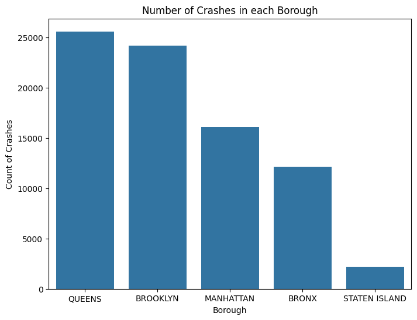

```python
# Plotting count of crashes in each borough
plt.figure(figsize=(8, 6))
sns.countplot(data=crash_total, x='BOROUGH',
              order=crash_total['BOROUGH'].value_counts().index)
plt.title('Number of Crashes in each Borough')
plt.xlabel('Borough')
plt.ylabel('Count of Crashes')
plt.show()
```

As shown in the above plot, Queens and Brooklyn have highest crash counts, and Staten Island has lowest crash counts.

### 2. Visualize the time distribution characteristics

First, we extract the Month and Day from the 'CRASH DATE' in the crash_total. We also get the standard form of the time in a day by applying to_datetime for 'CRASH TIME'.

```python
date_parts = crash_total["CRASH DATE"].str.split('/')

crash_total['Month'] = date_parts.apply(lambda x: int(x[0]))
crash_total['Day'] = date_parts.apply(lambda x: int(x[1]))

crash_total['CRASH TIME'] = pd.to_datetime(
    crash_total['CRASH TIME'], format='%H:%M', errors='coerce')
crash_total.head(3)
```

|  | CRASH DATE | CRASH TIME | BOROUGH | ZIP CODE | LATITUDE | LONGITUDE | LOCATION | ON STREET NAME | CROSS STREET NAME | OFF STREET NAME | ... | VEHICLE TYPE CODE 5 | street | avg_speed_limit | Timestamp | date | precipitation | new_snow | snow_depth | Month | Day |
| --- | --- | --- | --- | --- | --- | --- | --- | --- | --- | --- | --- | --- | --- | --- | --- | --- | --- | --- | --- | --- | --- |
| 0 | 05/21/2019 | 1900-01-01 22:50:00 | BROOKLYN | 11201.0 | 40.697540 | -73.98312 | (40.69754, -73.98312) | goldstreet | CONCORD STREET | NaN | ... | NaN | goldstreet | 25.0 | 2019-05-21 | 2019-05-21 | 0 | 0 | 0 | 5 | 21 |
| 1 | 12/14/2019 | 1900-01-01 11:35:00 | BROOKLYN | 11201.0 | 40.695908 | -73.98322 | (40.695908, -73.98322) | goldstreet | TILLARY STREET | NaN | ... | NaN | goldstreet | 25.0 | 2019-12-14 | 2019-12-14 | 1.13 | 0 | 0 | 12 | 14 |
| 2 | 12/17/2019 | 1900-01-01 18:00:00 | BROOKLYN | 11201.0 | 40.701360 | -73.98286 | (40.70136, -73.98286) | goldstreet | YORK STREET | NaN | ... | NaN | goldstreet | 25.0 | 2019-12-17 | 2019-12-17 | 0.9 | 0 | 0 | 12 | 17 |

3 rows × 38 columns

Then we create visualizations of crash counts concerning hourly, daily, and monthly time intervals.

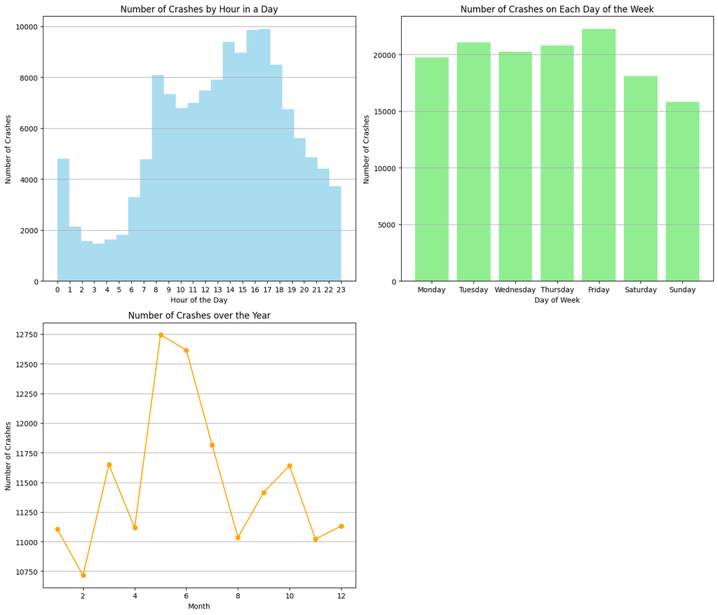

```python
# Create visulizations for the crash count across various time intervals
fig, axes = plt.subplots(nrows=2, ncols=2, figsize=(14, 12))

# Plot 1: Number of crashes by hour in a day
crash_total['Hour'] = crash_total['CRASH TIME'].dt.hour
axes[0, 0].hist(crash_total['Hour'], bins=24, alpha=0.7, color='skyblue')
axes[0, 0].set_title('Number of Crashes by Hour in a Day')
axes[0, 0].set_xlabel('Hour of the Day')
axes[0, 0].set_ylabel('Number of Crashes')
axes[0, 0].set_xticks(range(0, 24))
axes[0, 0].grid(axis='y')

# Plot 2: Number of crashes on each day of the week
crash_total['day'] = crash_total['Timestamp'].dt.dayofweek
crash_total['day'] = crash_total['day'].map(
    {0: 'Monday', 1: 'Tuesday', 2: 'Wednesday', 3: 'Thursday', 4: 'Friday', 5: 'Saturday', 6: 'Sunday'})
count_day = crash_total.groupby('day').size().reindex(
    ['Monday', 'Tuesday', 'Wednesday', 'Thursday', 'Friday', 'Saturday', 'Sunday'])
axes[0, 1].bar(count_day.index, count_day.values, color='lightgreen')
axes[0, 1].set_title('Number of Crashes on Each Day of the Week')
axes[0, 1].set_xlabel('Day of Week')
axes[0, 1].set_ylabel('Number of Crashes')
axes[0, 1].grid(axis='y')

# Plot 3: Number of crashes over the whole year
crash_total['Month'] = crash_total['Timestamp'].dt.month
count_month = crash_total.groupby('Month').size()
axes[1, 0].plot(count_month.index, count_month.values,
                marker='o', linestyle='-', color='orange')
axes[1, 0].set_title('Number of Crashes over the Year')
axes[1, 0].set_xlabel('Month')
axes[1, 0].set_ylabel('Number of Crashes')
axes[1, 0].grid(axis='y')

# Remove empty subplot
fig.delaxes(axes[1, 1])

plt.tight_layout()
plt.show()
```

From the plots above, we can find that: 1. In a single day, traffic crashes mainly concentrate in 8 am to 9 am, and 2 pm to 5 pm, which are the rush hours. 2. In a week, the number of crashes is high on weekdays (especially Friday), and low on weekends (especially Sunday). 3. In a year, the number of crashes is high in May and June, and low in February.

Then we categorize hours into time intervals. We decided to investigate the counts of crashes given specific combination of time interval and day of week. So, we use heatmap to visualize the results.

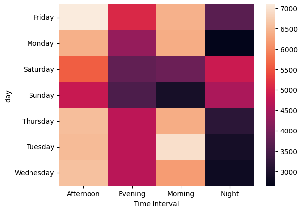

```python
# Function to categorize hours into time intervals
def categorize_time(hour):
    if 5 <= hour < 12:
        return 'Morning'
    elif 12 <= hour < 17:
        return 'Afternoon'
    elif 17 <= hour < 21:
        return 'Evening'
    else:
        return 'Night'


# Apply the function to create a new column 'Time Interval' based on hours
crash_total['Time Interval'] = crash_total['Hour'].apply(categorize_time)

ct = pd.crosstab(crash_total['day'], crash_total['Time Interval'])
sns.heatmap(ct, annot=False)
```

Through the heatmap we find that traffic accidents happened most on Friday afternoon and Tuesday morning. Even though Morning tends to be a time when traffic accidents are likely to happen, the frequency of traffic accidents happening on Sunday Morning is relatively low, which aligns with the common knowledge.

Next, we use bar plot to visualize the top 5 most common causes of crashes. As there're 5 contributing factors at most for each crash in our original dataset, we decide to count the contributing factor of vehicle 1 (which is the main participant of the traffic crash) as the cause of the crash.

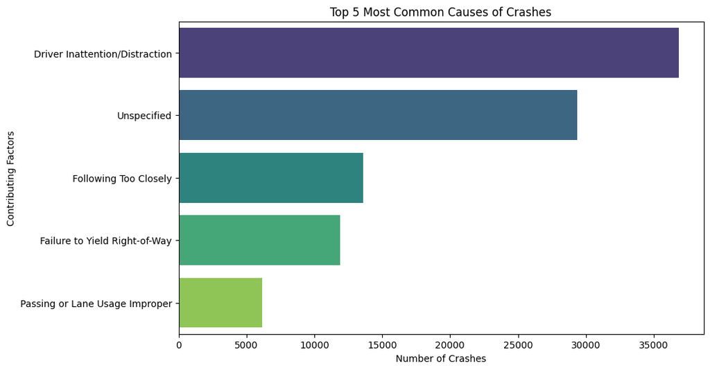

```python
count_causes = crash_total['CONTRIBUTING FACTOR VEHICLE 1'].value_counts()
top_10_causes = count_causes.head(5)
plt.figure(figsize=(10, 6))
sns.barplot(x=top_10_causes.values, y=top_10_causes.index, palette='viridis')
plt.title('Top 5 Most Common Causes of Crashes')
plt.xlabel('Number of Crashes')
plt.ylabel('Contributing Factors')
plt.show()
```

We can find from the above plot that driver inattention or distraction is the most common cause of traffic crashes.

We then calculate and visualize the sum of injuries and fatalities categorized by participant types (Pedestrians, Cyclists, and Motorists) using bar plots.

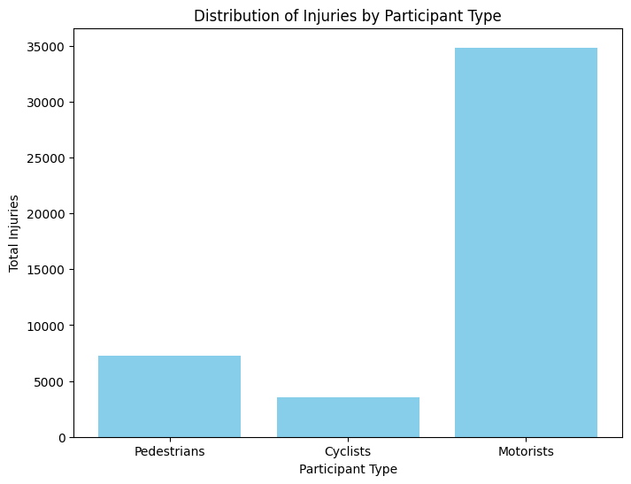

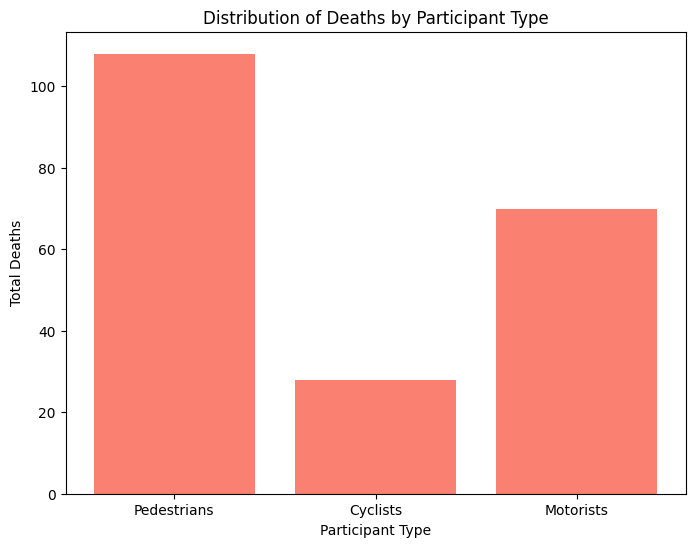

```python
# Summing up injuries and deaths for each participant type
pedestrian_injuries = crash_total['NUMBER OF PEDESTRIANS INJURED'].sum()
pedestrian_fatalities = crash_total['NUMBER OF PEDESTRIANS KILLED'].sum()

cyclist_injuries = crash_total['NUMBER OF CYCLIST INJURED'].sum()
cyclist_fatalities = crash_total['NUMBER OF CYCLIST KILLED'].sum()

motorist_injuries = crash_total['NUMBER OF MOTORIST INJURED'].sum()
motorist_fatalities = crash_total['NUMBER OF MOTORIST KILLED'].sum()

# Creating labels and data for the bar plot
labels = ['Pedestrians', 'Cyclists', 'Motorists']
injuries = [pedestrian_injuries, cyclist_injuries, motorist_injuries]
fatalities = [pedestrian_fatalities, cyclist_fatalities, motorist_fatalities]

# Plotting a bar plot for injuries
plt.figure(figsize=(8, 6))
plt.bar(labels, injuries, color='skyblue')
plt.title('Distribution of Injuries by Participant Type')
plt.xlabel('Participant Type')
plt.ylabel('Total Injuries')
plt.show()

# Plotting a bar plot for fatalities
plt.figure(figsize=(8, 6))
plt.bar(labels, fatalities, color='salmon')
plt.title('Distribution of Deaths by Participant Type')
plt.xlabel('Participant Type')
plt.ylabel('Total Deaths')
plt.show()
```

From the first bar plot above (visualizing injuries), we can find that motorists have the highest count of injuries, this might be because most traffic crashes happen between motor vehicles, according to common sense. However, as we can find from the below barplot (visualizing deaths), pedestrians have the highest number of deaths. This indicates that pedestrians are vulnerable groups and are more likely to die in traffic crashes.

## Machine learning

### Feature engineering

First, we classify the severity of the crashes based on the number of persons injured and killed. To be specific, we identify the crash to be 'severe' if there are more than 0 people died or more than 2 people injured. We identify the severity to be 'moderate' if there are more than 0 people injured. Else, for those crashes with no one died or injured, we identify the crash's severity to be 'minor'.

```python
def categorize_severity(row):
    injuries = row['NUMBER OF PERSONS INJURED']
    deaths = row['NUMBER OF PERSONS KILLED']

    if deaths > 0 or injuries > 2:
        return 'severe'
    elif injuries > 0:
        return 'moderate'
    else:
        return 'minor'


# Apply the function to create a new column 'severity' based on injuries and deaths
crash_total['severity'] = crash_total.apply(categorize_severity, axis=1)
```

```python
crash_total.head(5)
```

|  | CRASH DATE | CRASH TIME | BOROUGH | ZIP CODE | LATITUDE | LONGITUDE | LOCATION | ON STREET NAME | CROSS STREET NAME | OFF STREET NAME | ... | date | precipitation | new_snow | snow_depth | Month | Day | Hour | day | Time Interval | severity |
| --- | --- | --- | --- | --- | --- | --- | --- | --- | --- | --- | --- | --- | --- | --- | --- | --- | --- | --- | --- | --- | --- |
| 0 | 05/21/2019 | 1900-01-01 22:50:00 | BROOKLYN | 11201.0 | 40.697540 | -73.98312 | (40.69754, -73.98312) | goldstreet | CONCORD STREET | NaN | ... | 2019-05-21 | 0 | 0 | 0 | 5 | 21 | 22 | Tuesday | Night | minor |
| 1 | 12/14/2019 | 1900-01-01 11:35:00 | BROOKLYN | 11201.0 | 40.695908 | -73.98322 | (40.695908, -73.98322) | goldstreet | TILLARY STREET | NaN | ... | 2019-12-14 | 1.13 | 0 | 0 | 12 | 14 | 11 | Saturday | Morning | minor |
| 2 | 12/17/2019 | 1900-01-01 18:00:00 | BROOKLYN | 11201.0 | 40.701360 | -73.98286 | (40.70136, -73.98286) | goldstreet | YORK STREET | NaN | ... | 2019-12-17 | 0.9 | 0 | 0 | 12 | 17 | 18 | Tuesday | Evening | moderate |
| 3 | 12/01/2019 | 1900-01-01 01:10:00 | NaN | NaN | 40.697540 | -73.98312 | (40.69754, -73.98312) | goldstreet | NaN | NaN | ... | 2019-12-01 | 0 | 0 | 0 | 12 | 1 | 1 | Sunday | Night | moderate |
| 4 | 11/25/2019 | 1900-01-01 10:06:00 | NaN | NaN | 40.710800 | -74.00342 | (40.7108, -74.00342) | goldstreet | FRANKFORT STREET | NaN | ... | 2019-11-25 | 0 | 0 | 0 | 11 | 25 | 10 | Monday | Morning | minor |

5 rows × 42 columns

Then we map the severity labels to numerical values and select some features from the primary dataset (the time of the crashes), as well as the features that are merged from the secondary data sets (speed limit and weather features) as the features.

```python
severity_mapping = {'minor': 0, 'moderate': 1, 'severe': 2}
crash_total['severity_encoded'] = crash_total['severity'].map(severity_mapping)
```

```python
selected_columns = ['precipitation', 'new_snow', 'Hour', 'snow_depth',
                    'day', 'avg_speed_limit', 'Month', 'Time Interval', 'severity_encoded']
crash_ml = crash_total[selected_columns]
```

We also apply one-hot encoding for the categorical data including 'day' and 'Time Interval'.

```python
# one-hot encoding
from sklearn.preprocessing import OneHotEncoder
encoder = OneHotEncoder()
for column in ["day", "Time Interval"]:
    onehot_encoded = encoder.fit_transform(crash_ml[[column]])
    onehot_df = pd.DataFrame(onehot_encoded.toarray(
    ), columns=encoder.get_feature_names_out([column]))
    crash_ml = pd.concat([crash_ml, onehot_df], axis=1)
```

```python
crash_ml = crash_ml.drop(
    ["day", "Time Interval"], axis=1)
crash_ml.head(3)
```

|  | precipitation | new_snow | Hour | snow_depth | avg_speed_limit | Month | severity_encoded | day_Friday | day_Monday | day_Saturday | day_Sunday | day_Thursday | day_Tuesday | day_Wednesday | Time Interval_Afternoon | Time Interval_Evening | Time Interval_Morning | Time Interval_Night |
| --- | --- | --- | --- | --- | --- | --- | --- | --- | --- | --- | --- | --- | --- | --- | --- | --- | --- | --- |
| 0 | 0 | 0 | 22 | 0 | 25.0 | 5 | 0 | 0.0 | 0.0 | 0.0 | 0.0 | 0.0 | 1.0 | 0.0 | 0.0 | 0.0 | 0.0 | 1.0 |
| 1 | 1.13 | 0 | 11 | 0 | 25.0 | 12 | 0 | 0.0 | 0.0 | 1.0 | 0.0 | 0.0 | 0.0 | 0.0 | 0.0 | 0.0 | 1.0 | 0.0 |
| 2 | 0.9 | 0 | 18 | 0 | 25.0 | 12 | 1 | 0.0 | 0.0 | 0.0 | 0.0 | 0.0 | 1.0 | 0.0 | 0.0 | 1.0 | 0.0 | 0.0 |

### Train and test using Gradient Boosting

In this part, we first split the train and test data from the dataset, then apply gradient boosting to predict the severity of the crashes.

```python
# split train and test data
from sklearn.model_selection import train_test_split
# "target" contains the column name of the classification labels
target = "severity_encoded"
X = crash_ml.drop(target, axis=1)
y = crash_ml[target]
random_state = 50
test_size = 0.33
X_train, X_test, y_train, y_test = train_test_split(
    X, y, test_size=test_size, random_state=random_state)
```

```python
# gradient boosting
from sklearn.ensemble import GradientBoostingClassifier
gb_model = GradientBoostingClassifier(random_state=50)
gb_model.fit(X_train, y_train)
gb_pred = gb_model.predict(X_test)
```

We also visualize the importance of the features to see the leading features affecting the severity of crashes.

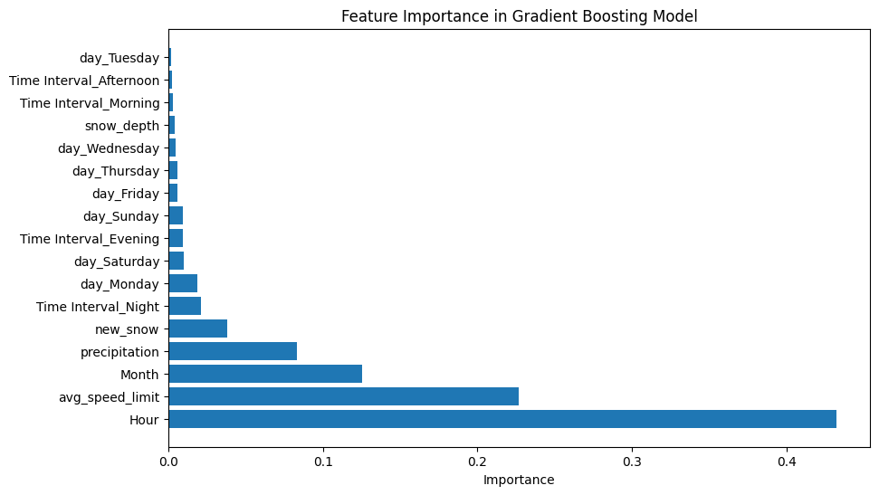

```python
# visualize feature importance
feature_importances = gb_model.feature_importances_
feature_importance_df = pd.DataFrame(
    {'Feature': X_train.columns, 'Importance': feature_importances})
feature_importance_df = feature_importance_df.sort_values(
    by='Importance', ascending=False)
plt.figure(figsize=(10, 6))
plt.barh(feature_importance_df['Feature'], feature_importance_df['Importance'])
plt.xlabel('Importance')
plt.title('Feature Importance in Gradient Boosting Model')
plt.show()
```

As we can see from the above plot, Hour, average speed limit of the street, Month, precipitation and new_snow are the top 5 leading features affecting the severity of crashes.

Finally, we use the test set to obtain the accuracy of our model and get the accuracy of 0.758.

```python
from sklearn.metrics import accuracy_score
print("Gradient Boosting Accuracy:", accuracy_score(y_test, gb_pred))
```

```
Gradient Boosting Accuracy: 0.7587993764134994
```

[figure not shown]

Created in Deepnote